# Solar Power Gen

Import all necessary libraries and files

```python
import pandas as pd
import numpy as np
import tensorflow as tf
from tensorflow import keras
import matplotlib.pyplot as plt
```

```python
plant1_gen_dataset = pd.read_csv("/content/drive/My Drive/ML Project downloads/soloarpowergen/Plant_1_Generation_Data.csv")
plant1_weather_dataset = pd.read_csv("/content/drive/My Drive/ML Project downloads/soloarpowergen/Plant_1_Weather_Sensor_Data.csv")
plant2_gen_dataset = pd.read_csv("/content/drive/My Drive/ML Project downloads/soloarpowergen/Plant_2_Generation_Data.csv")
plant2_weather_dataset = pd.read_csv("/content/drive/My Drive/ML Project downloads/soloarpowergen/Plant_2_Weather_Sensor_Data.csv")
```

Lets get an overview of the data to get an idea what we are working with

```python
plant1_gen_dataset.head(),plant1_weather_dataset.head()
```

```
(          DATE_TIME  PLANT_ID  ... DAILY_YIELD  TOTAL_YIELD
 0  15-05-2020 00:00   4135001  ...         0.0    6259559.0
 1  15-05-2020 00:00   4135001  ...         0.0    6183645.0
 2  15-05-2020 00:00   4135001  ...         0.0    6987759.0
 3  15-05-2020 00:00   4135001  ...         0.0    7602960.0
 4  15-05-2020 00:00   4135001  ...         0.0    7158964.0

 [5 rows x 7 columns],
              DATE_TIME  PLANT_ID  ... MODULE_TEMPERATURE  IRRADIATION
 0  2020-05-15 00:00:00   4135001  ...          22.857507          0.0
 1  2020-05-15 00:15:00   4135001  ...          22.761668          0.0
 2  2020-05-15 00:30:00   4135001  ...          22.592306          0.0
 3  2020-05-15 00:45:00   4135001  ...          22.360852          0.0
 4  2020-05-15 01:00:00   4135001  ...          22.165423          0.0

 [5 rows x 6 columns])
```

```python
plant1_gen_dataset.info(),plant2_weather_dataset.info()
```

```
<class 'pandas.core.frame.DataFrame'>
RangeIndex: 68778 entries, 0 to 68777
Data columns (total 7 columns):
 #   Column       Non-Null Count  Dtype
---  ------       --------------  -----
 0   DATE_TIME    68778 non-null  object
 1   PLANT_ID     68778 non-null  int64
 2   SOURCE_KEY   68778 non-null  object
 3   DC_POWER     68778 non-null  float64
 4   AC_POWER     68778 non-null  float64
 5   DAILY_YIELD  68778 non-null  float64
 6   TOTAL_YIELD  68778 non-null  float64
dtypes: float64(4), int64(1), object(2)
memory usage: 3.7+ MB
<class 'pandas.core.frame.DataFrame'>
RangeIndex: 3259 entries, 0 to 3258
Data columns (total 6 columns):
 #   Column               Non-Null Count  Dtype
---  ------               --------------  -----
 0   DATE_TIME            3259 non-null   object
 1   PLANT_ID             3259 non-null   int64
 2   SOURCE_KEY           3259 non-null   object
 3   AMBIENT_TEMPERATURE  3259 non-null   float64
 4   MODULE_TEMPERATURE   3259 non-null   float64
 5   IRRADIATION          3259 non-null   float64
dtypes: float64(3), int64(1), object(2)
memory usage: 152.9+ KB
```

```
(None, None)
```

# Data Cleaning

The date_time column for the files are in different formats. Lets standardise them and merge the files together.

```python
from datetime import datetime

def standardise_datetime(date_str):
  try:
    return datetime.strptime(date_str, '%Y-%m-%d %H:%M:%S')
  except:
    return datetime.strptime(date_str, '%d-%m-%Y %H:%M')

for df in [plant1_gen_dataset, plant1_weather_dataset, plant2_gen_dataset, plant2_weather_dataset]:
  df["DATE_TIME"] = df.DATE_TIME.apply(standardise_datetime)
  df = df.sort_values("DATE_TIME")
```

```python
plant1_full = pd.merge(plant1_gen_dataset, plant1_weather_dataset.drop(["PLANT_ID"], axis=1), "inner", on = "DATE_TIME")
plant2_full = pd.merge(plant2_gen_dataset, plant2_weather_dataset.drop(["PLANT_ID"], axis=1), "inner", on = "DATE_TIME")
plant_all = pd.concat([plant1_full, plant2_full])
plant_all.head()
```

|  | DATE_TIME | PLANT_ID | SOURCE_KEY_x | DC_POWER | AC_POWER | DAILY_YIELD | TOTAL_YIELD | SOURCE_KEY_y | AMBIENT_TEMPERATURE | MODULE_TEMPERATURE | IRRADIATION |
| --- | --- | --- | --- | --- | --- | --- | --- | --- | --- | --- | --- |
| 0 | 2020-05-15 | 4135001 | 1BY6WEcLGh8j5v7 | 0.0 | 0.0 | 0.0 | 6259559.0 | HmiyD2TTLFNqkNe | 25.184316 | 22.857507 | 0.0 |
| 1 | 2020-05-15 | 4135001 | 1IF53ai7Xc0U56Y | 0.0 | 0.0 | 0.0 | 6183645.0 | HmiyD2TTLFNqkNe | 25.184316 | 22.857507 | 0.0 |
| 2 | 2020-05-15 | 4135001 | 3PZuoBAID5Wc2HD | 0.0 | 0.0 | 0.0 | 6987759.0 | HmiyD2TTLFNqkNe | 25.184316 | 22.857507 | 0.0 |
| 3 | 2020-05-15 | 4135001 | 7JYdWkrLSPkdwr4 | 0.0 | 0.0 | 0.0 | 7602960.0 | HmiyD2TTLFNqkNe | 25.184316 | 22.857507 | 0.0 |
| 4 | 2020-05-15 | 4135001 | McdE0feGgRqW7Ca | 0.0 | 0.0 | 0.0 | 7158964.0 | HmiyD2TTLFNqkNe | 25.184316 | 22.857507 | 0.0 |

Next, we transform date and time in terms of sine and cosine to preserve its cyclical significance.

```python
#Get time in sine and cos
day = 24*60*60
year = (365.2425)*day

timestamps = plant_all.DATE_TIME
timestamps = timestamps.map(datetime.timestamp)

plant_all["DAY_COS"] = np.cos(timestamps * (2 * np.pi / day))
plant_all["DAY_SIN"] = np.sin(timestamps * (2 * np.pi / day))
plant_all["YEAR_COS"] = np.cos(timestamps * (2 * np.pi / year))
plant_all["YEAR_SIN"] = np.sin(timestamps * (2 * np.pi / year))

plant_all.describe().transpose()
```

|  | count | mean | std | min | 25% | 50% | 75% | max |
| --- | --- | --- | --- | --- | --- | --- | --- | --- |
| PLANT_ID | 136472.0 | 4.135497e+06 | 4.999863e+02 | 4.135001e+06 | 4.135001e+06 | 4.135001e+06 | 4.136001e+06 | 4.136001e+06 |
| DC_POWER | 136472.0 | 1.708374e+03 | 3.222079e+03 | 0.000000e+00 | 0.000000e+00 | 5.993333e+00 | 1.155595e+03 | 1.447112e+04 |
| AC_POWER | 136472.0 | 2.747903e+02 | 3.801802e+02 | 0.000000e+00 | 0.000000e+00 | 3.493095e+00 | 5.325686e+02 | 1.410950e+03 |
| DAILY_YIELD | 136472.0 | 3.295366e+03 | 3.035313e+03 | 0.000000e+00 | 2.828571e+01 | 2.834643e+03 | 5.992000e+03 | 9.873000e+03 |
| TOTAL_YIELD | 136472.0 | 3.303916e+08 | 6.085769e+08 | 0.000000e+00 | 6.520020e+06 | 7.269333e+06 | 2.826096e+08 | 2.247916e+09 |
| AMBIENT_TEMPERATURE | 136472.0 | 2.676307e+01 | 3.897340e+00 | 2.039850e+01 | 2.363760e+01 | 2.590812e+01 | 2.926658e+01 | 3.918164e+01 |
| MODULE_TEMPERATURE | 136472.0 | 3.192074e+01 | 1.180367e+01 | 1.814042e+01 | 2.241170e+01 | 2.641376e+01 | 4.077858e+01 | 6.663595e+01 |
| IRRADIATION | 136472.0 | 2.307669e-01 | 3.056523e-01 | 0.000000e+00 | 0.000000e+00 | 2.621286e-02 | 4.429609e-01 | 1.221652e+00 |
| DAY_COS | 136472.0 | -7.166717e-03 | 7.076213e-01 | -1.000000e+00 | -7.071068e-01 | -7.235672e-12 | 7.071068e-01 | 1.000000e+00 |
| DAY_SIN | 136472.0 | -3.279095e-03 | 7.065531e-01 | -1.000000e+00 | -7.071068e-01 | -2.187879e-12 | 7.071068e-01 | 1.000000e+00 |
| YEAR_COS | 136472.0 | -8.543586e-01 | 8.547759e-02 | -9.721282e-01 | -9.302478e-01 | -8.700556e-01 | -7.855203e-01 | -6.812203e-01 |
| YEAR_SIN | 136472.0 | 4.915960e-01 | 1.452533e-01 | 2.344501e-01 | 3.669318e-01 | 4.929536e-01 | 6.188359e-01 | 7.320785e-01 |

Lets plot DC_power over time to visualise how DC power generation and other features correlates with time

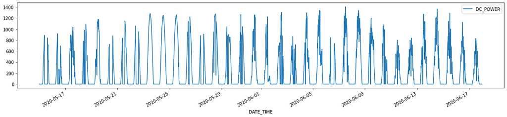

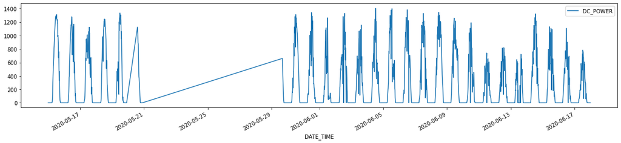

```python
key1 = "xoJJ8DcxJEcupym"
key2 = "xMbIugepa2P7lBB"

df1 = plant_all[plant_all["SOURCE_KEY_x"] == key1]
df2 = plant_all[plant_all["SOURCE_KEY_x"] == key2]

no_of_days = 30
DAYS = no_of_days * 96

df1.plot(x="DATE_TIME", y="DC_POWER", figsize=(20,4))
df2.plot(x="DATE_TIME", y="DC_POWER", figsize=(20,4))
```

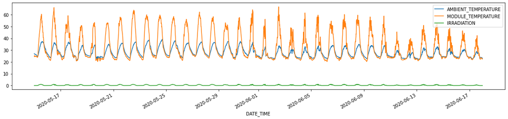

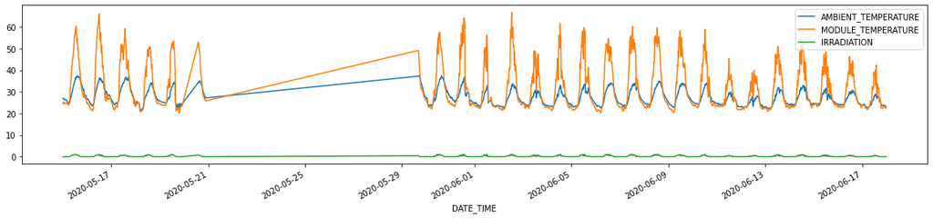

```python
no_of_days = 3
DAYS = no_of_days * 96

df1.plot(x="DATE_TIME", y=["AMBIENT_TEMPERATURE", "MODULE_TEMPERATURE", "IRRADIATION"], figsize=(20,4))
df2.plot(x="DATE_TIME", y=["AMBIENT_TEMPERATURE", "MODULE_TEMPERATURE", "IRRADIATION"], figsize=(20,4))

# plt.figure(figsize=(8*no_of_days,4))
# plt.xticks(np.arange(0, DAYS, step=4), rotation=90)

# plt.plot(df1["DATE_TIME"][:DAYS], df1["AMBIENT_TEMPERATURE"][:DAYS], "r", label="AMBIENT_TEMPERATURE" )
# plt.plot(df1["DATE_TIME"][:DAYS], df1["MODULE_TEMPERATURE"][:DAYS], "b", label="MODULE_TEMPERATURE")
# plt.plot(df1["DATE_TIME"][:DAYS], df1["IRRADIATION"][:DAYS], "g", label="IRRADIATION")

# plt.plot(df2["DATE_TIME"][:DAYS], df2["AMBIENT_TEMPERATURE"][:DAYS], "r--", label="AMBIENT_TEMPERATURE" )
# plt.plot(df2["DATE_TIME"][:DAYS], df2["MODULE_TEMPERATURE"][:DAYS], "b--", label="MODULE_TEMPERATURE")
# plt.plot(df2["DATE_TIME"][:DAYS], df2["IRRADIATION"][:DAYS], "g--", label="IRRADIATION")
# plt.legend()
```

Lets drop columns that we will not need

```python
key = "1BY6WEcLGh8j5v7"
plant_all[plant_all["SOURCE_KEY_x"] == key].drop(["PLANT_ID", "SOURCE_KEY_x", "SOURCE_KEY_y", "IRRADIATION", "TOTAL_YIELD", "DAILY_YIELD"], axis=1)
```

|  | DATE_TIME | DC_POWER | AC_POWER | AMBIENT_TEMPERATURE | MODULE_TEMPERATURE | DAY_COS | DAY_SIN | YEAR_COS | YEAR_SIN |
| --- | --- | --- | --- | --- | --- | --- | --- | --- | --- |
| 0 | 2020-05-15 00:00:00 | 0.0 | 0.0 | 25.184316 | 22.857507 | 1.000000 | -9.444237e-12 | -0.681220 | 0.732078 |
| 21 | 2020-05-15 00:15:00 | 0.0 | 0.0 | 25.084589 | 22.761668 | 0.997859 | 6.540313e-02 | -0.681351 | 0.731956 |
| 42 | 2020-05-15 00:30:00 | 0.0 | 0.0 | 24.935753 | 22.592306 | 0.991445 | 1.305262e-01 | -0.681483 | 0.731834 |
| 63 | 2020-05-15 00:45:00 | 0.0 | 0.0 | 24.846130 | 22.360852 | 0.980785 | 1.950903e-01 | -0.681614 | 0.731712 |
| 84 | 2020-05-15 01:00:00 | 0.0 | 0.0 | 24.621525 | 22.165423 | 0.965926 | 2.588190e-01 | -0.681745 | 0.731590 |
| ... | ... | ... | ... | ... | ... | ... | ... | ... | ... |
| 68664 | 2020-06-17 22:45:00 | 0.0 | 0.0 | 22.150570 | 21.480377 | 0.946930 | -3.214395e-01 | -0.971960 | 0.235147 |
| 68686 | 2020-06-17 23:00:00 | 0.0 | 0.0 | 22.129816 | 21.389024 | 0.965926 | -2.588190e-01 | -0.972002 | 0.234973 |
| 68708 | 2020-06-17 23:15:00 | 0.0 | 0.0 | 22.008275 | 20.709211 | 0.980785 | -1.950903e-01 | -0.972044 | 0.234798 |
| 68730 | 2020-06-17 23:30:00 | 0.0 | 0.0 | 21.969495 | 20.734963 | 0.991445 | -1.305262e-01 | -0.972086 | 0.234624 |
| 68752 | 2020-06-17 23:45:00 | 0.0 | 0.0 | 21.909288 | 20.427972 | 0.997859 | -6.540313e-02 | -0.972128 | 0.234450 |

3154 rows × 9 columns

Lets cut the data into short sequences which will use to train the model

```
(572, 58, 8)
```

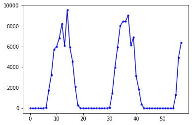

```python
date_list = np.array(pd.DataFrame(pd.date_range(start='15-05-2020', end='17-06-2020', freq="15min"), columns=["DATETIME"]).DATETIME.apply(lambda x: standardise_datetime(str(x))))

def get_seq(days=1):
  length = days * 96
  dataset = []
  count = 0
  prev_value = np.array([0 for i in range(8)])
  for key in plant_all.SOURCE_KEY_x.unique():
    new_set = []
    key_set = plant_all[plant_all["SOURCE_KEY_x"] == key].drop(["PLANT_ID", "SOURCE_KEY_x", "SOURCE_KEY_y", "IRRADIATION", "TOTAL_YIELD", "DAILY_YIELD"], axis=1).to_numpy()
    for d in date_list:
      if d == key_set[count][0]:
        new_set.append(key_set[count][1:])
        count+=1
      else:
        new_set.append(prev_value)
      # prev_value = key_set[count][1:]
      if len(new_set) >= length:
        dataset.append(new_set)
        new_set = []

    count = 0
  return np.array(dataset).astype(np.float32)

#Convert to 1hr interval
dc_dataset = get_seq(days = 2.4)
dc_dataset = dc_dataset[:,::4]
print(dc_dataset.shape)
plt.plot(dc_dataset[0,:,0], "b.-")
```

We will shuffle the dataset and then split them into training and validation sets.

```python
np.random.shuffle(dc_dataset)
train_size = len(dc_dataset) * 70 // 100
valid_size = len(dc_dataset) * 20 // 100


train_set  = dc_dataset[:train_size]
valid_set = dc_dataset[train_size:train_size + valid_size]
test_set = dc_dataset[train_size + valid_size:]

train_set.shape, valid_set.shape, test_set.shape
```

```
((400, 58, 8), (114, 58, 8), (58, 58, 8))
```

Normalising the data so that all features are on similiar scale.

```python
#Normalising
train_mean = train_set.mean()
train_std = train_set.std()

train_set = (train_set-train_mean)/train_std
valid_set = (valid_set-train_mean)/train_std
test_set = (test_set-train_mean)/train_std
```

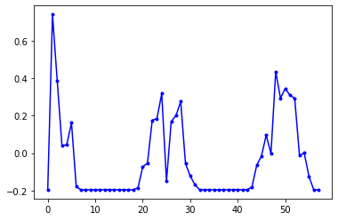

```python
plt.plot(test_set[5,:,0], "b.-")
```

```
(400, 34, 8) (400, 24, 1)
```

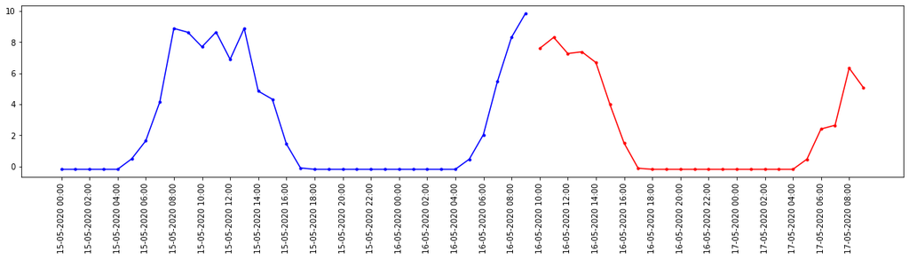

```python
n_steps = 34
pred_steps = 24

date_list_hr = np.array(
    pd.DataFrame(pd.date_range(start='15-05-2020', end='17-06-2020', freq="1h"), columns=["DATETIME"]).DATETIME.apply(lambda x: standardise_datetime(str(x)).strftime('%d-%m-%Y %H:%M'))
    )


X_train, y_train = train_set[:, :n_steps], train_set[:, n_steps: n_steps+pred_steps, :1]
X_valid, y_valid = valid_set[:, :n_steps], valid_set[:, n_steps: n_steps+pred_steps, :1]
X_test, y_test = test_set[:, :n_steps], test_set[:, n_steps: n_steps+pred_steps, :1]

print(X_train.shape, y_train.shape)

plt.figure(figsize=(20,4))
plt.xticks(np.arange(0, n_steps+pred_steps, step=2), rotation=90)
plt.plot(date_list_hr[:n_steps],X_train[0,:,0],"b.-")
plt.plot(date_list_hr[n_steps:n_steps+pred_steps],y_train[0,:,0],"r.-")
```

We will tweak the dataset so that the model can make longer predictions at every time step

```python
def pred_every_timestep(dataset, n_steps, pred_steps):
  Y = np.empty((dataset.shape[0], n_steps, pred_steps))
  for i in range(1, pred_steps+1):
    Y[..., i-1] = dataset[..., i:i+n_steps, 0]
  return Y

y_train_2 = pred_every_timestep(train_set, n_steps, pred_steps)
y_valid_2 = pred_every_timestep(valid_set, n_steps, pred_steps)
y_test_2 = pred_every_timestep(test_set, n_steps, pred_steps)

X_valid.shape, y_valid_2.shape
```

```
((114, 34, 8), (114, 34, 24))
```

## Multi-step LSTM

```python
np.random.seed(42)
tf.random.set_seed(42)

model = keras.models.Sequential([
    keras.layers.LSTM(20, return_sequences=True),
    keras.layers.LSTM(20),
    keras.layers.Dense(pred_steps),
    # keras.layers.Reshape([pred_steps, 5])
])

early_stopping_cb = keras.callbacks.EarlyStopping(patience=20, restore_best_weights=True)
reduce_lr_cb = keras.callbacks.ReduceLROnPlateau(factor=0.5)

model.compile(loss="mse", optimizer="adam")
history = model.fit(X_train, y_train, epochs=200,
                    validation_data=(X_valid, y_valid), callbacks=[early_stopping_cb,reduce_lr_cb])
```

Lets plot the validation loss against training lost to determine if the model is undertrained or overtrained.

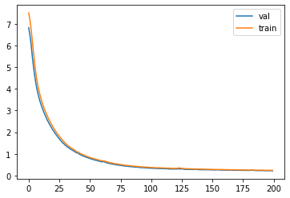

```python
plt.plot(history.history["val_loss"], label="val")
plt.plot(history.history["loss"], label="train")
plt.legend()
```

After training the model, we can give it a test instance and see how it performs compared to the actual result

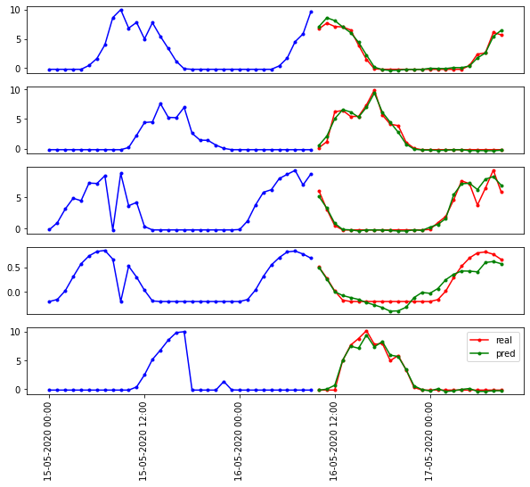

```python
y_pred = model.predict(X_test)

plt.figure(figsize=(10,8))
for i in range(5):
  plt.subplot(5,1,i+1)
  plt.xticks([])
  plt.plot(date_list_hr[:n_steps],X_test[i,:,0], "b.-")
  plt.plot(date_list_hr[n_steps: n_steps+pred_steps],y_test[i,:,0],"r.-", label="real")
  plt.plot(date_list_hr[n_steps: n_steps+pred_steps],y_pred[i,:], "g.-", label="pred")
plt.legend()
plt.xticks(np.arange(0, n_steps+pred_steps, step=12), rotation=90)
plt.show()
```

## Multi-step at every step using convolutional layers

```python
np.random.seed(42)
tf.random.set_seed(42)

#Calculate mse for last point in pred
def last_time_step_mse(Y_true, Y_pred):
    return keras.metrics.mean_squared_error(Y_true[:, -1], Y_pred[:, -1])

model_conv = keras.models.Sequential([
    keras.layers.Conv1D(filters=256, kernel_size=4, strides=2, padding="valid",activation='relu'),
    keras.layers.LSTM(20, return_sequences=True),
    keras.layers.LSTM(20, return_sequences=True),
    keras.layers.Dense(pred_steps),
    # keras.layers.Reshape([1,pred_steps])
])

model_conv.compile(loss="mse", optimizer="adam", metrics=[last_time_step_mse])
#3::2 because stride is 2, and we ignore first three value because first output of conv layer is based on input time 0-3
history = model_conv.fit(X_train, y_train_2[:, 3::2], epochs=200,
                    validation_data=(X_valid, y_valid_2[:, 3::2]))
```

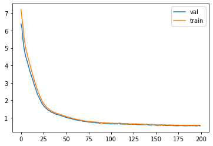

```python
plt.plot(history.history["val_last_time_step_mse"], label="val")
plt.plot(history.history["last_time_step_mse"], label="train")
plt.legend()
```

We will plot the new model together with the previous model

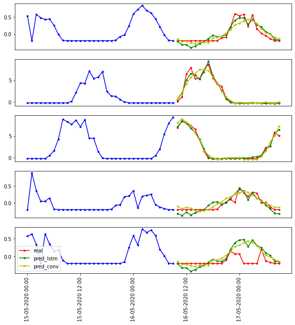

```python
y_pred_conv = model_conv.predict(X_test)[:, -1][..., np.newaxis]
y_pred_lstm = model.predict(X_test)


plt.figure(figsize=(10,10))
for i in range(5):
  plt.subplot(5,1,i+1)
  plt.xticks([])
  plt.plot(date_list_hr[:n_steps],X_test[i+10,:,0], "b.-")
  plt.plot(date_list_hr[n_steps: n_steps+pred_steps],y_test[i+10,:,0],"r.-", label="real")
  plt.plot(date_list_hr[n_steps: n_steps+pred_steps],y_pred_lstm[i+10,:], "g.-", label="pred_lstm")
  plt.plot(date_list_hr[n_steps: n_steps+pred_steps],y_pred_conv[i+10,:], "y.-", label="pred_conv")
plt.legend()
plt.xticks(np.arange(0, n_steps+pred_steps, step=12), rotation=90)
plt.show()
```

```python
model_conv.evaluate(X_test, y_test_2[:,3::2])
```

```
[1.0257858037948608, 0.7111430168151855]
```

## Wave Net

```python
model_wave = keras.models.Sequential()
model_wave.add(keras.layers.InputLayer(input_shape=[None, X_train.shape[2]]))
for rate in (1, 2, 4, 8) * 2:
    model_wave.add(keras.layers.Conv1D(filters=20, kernel_size=2, padding="causal",
                                  activation="relu", dilation_rate=rate))
model_wave.add(keras.layers.Conv1D(filters=pred_steps, kernel_size=1))


model_wave.compile(loss="mse", optimizer="adam", metrics=[last_time_step_mse])
history = model_wave.fit(X_train, y_train_2, epochs=100,
                    validation_data=(X_valid, y_valid_2))
```

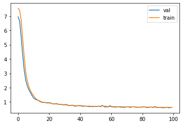

```python
plt.plot(history.history["val_last_time_step_mse"], label="val")
plt.plot(history.history["last_time_step_mse"], label="train")
plt.legend()
```

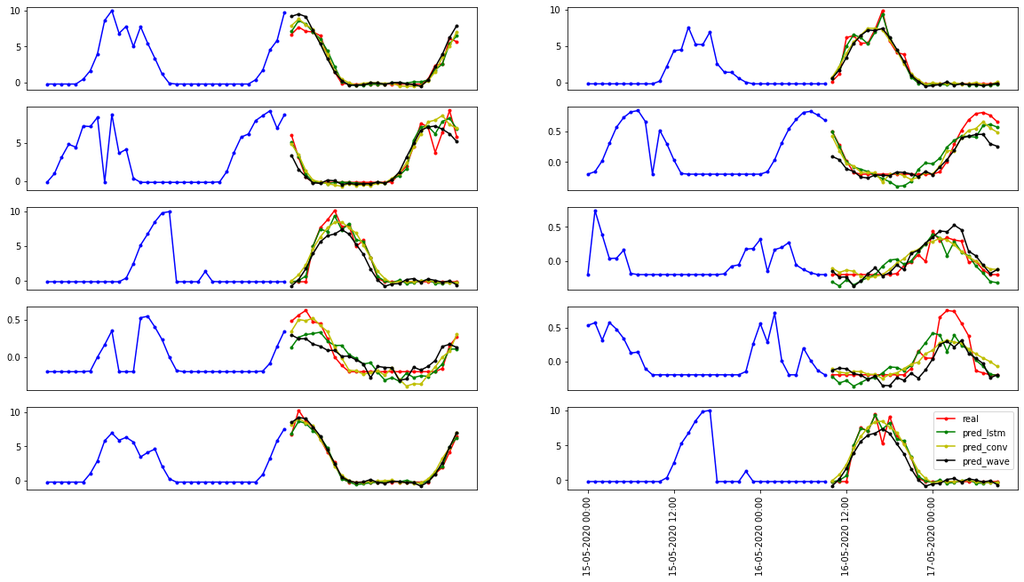

```python
y_pred_conv = model_conv.predict(X_test)[:, -1][..., np.newaxis]
y_pred_lstm = model.predict(X_test)
y_pred_wave = model_wave.predict(X_test)[:, -1][..., np.newaxis]

plt.figure(figsize=(20,10))
for i in range(10):
  plt.subplot(5,2,i+1)
  plt.xticks([])
  plt.plot(date_list_hr[:n_steps],X_test[i,:,0], "b.-")
  plt.plot(date_list_hr[n_steps: n_steps+pred_steps],y_test[i,:,0],"r.-", label="real")
  plt.plot(date_list_hr[n_steps: n_steps+pred_steps],y_pred_lstm[i,:], "g.-", label="pred_lstm")
  plt.plot(date_list_hr[n_steps: n_steps+pred_steps],y_pred_conv[i,:], "y.-", label="pred_conv")
  plt.plot(date_list_hr[n_steps: n_steps+pred_steps],y_pred_wave[i,:,0], "k.-", label="pred_wave")
plt.legend()
plt.xticks(np.arange(0, n_steps+pred_steps, step=12), rotation=90)
plt.show()
```

## Multi-step at every step LSTM

```python
np.random.seed(42)
tf.random.set_seed(42)

model_lstm = keras.models.Sequential([
    keras.layers.LSTM(20, return_sequences=True),
    keras.layers.LSTM(20, return_sequences=True),
    keras.layers.Dense(pred_steps),
    # keras.layers.Reshape([pred_steps, 5])
])

early_stopping_cb = keras.callbacks.EarlyStopping(patience=20, restore_best_weights=True)
reduce_lr_cb = keras.callbacks.ReduceLROnPlateau(factor=0.5, verbose=1)

model_lstm.compile(loss="mse", optimizer="adam", metrics=[last_time_step_mse])
history = model_lstm.fit(X_train, y_train_2, epochs=200,
                    validation_data=(X_valid, y_valid_2), callbacks=[early_stopping_cb,reduce_lr_cb])
```

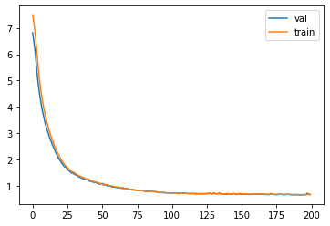

```python
plt.plot(history.history["val_last_time_step_mse"], label="val")
plt.plot(history.history["last_time_step_mse"], label="train")
plt.legend()
```

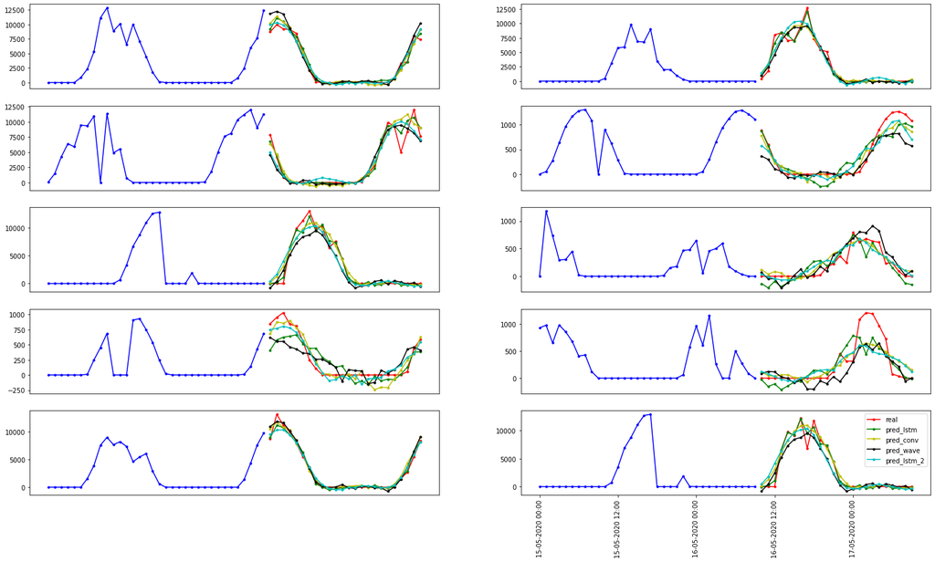

```python
y_pred_conv = model_conv.predict(X_test)[:, -1][..., np.newaxis] * train_std + train_mean
y_pred_lstm = model.predict(X_test) * train_std + train_mean
y_pred_wave = model_wave.predict(X_test)[:, -1][..., np.newaxis] * train_std + train_mean
y_pred_lstm_2 = model_lstm.predict(X_test)[:, -1][..., np.newaxis] * train_std + train_mean

#Just copy previous day
from sklearn.metrics import mean_squared_error
y_pred = X_test[:,:,0]



plt.figure(figsize=(25,14))
for i in range(10):
  plt.subplot(5,2,i+1)
  plt.xticks([])
  plt.plot(date_list_hr[:n_steps],X_test[i,:,0]*train_std + train_mean, "b.-")
  plt.plot(date_list_hr[n_steps: n_steps+pred_steps],y_test[i,:,0]*train_std + train_mean,"r.-", label="real")
  plt.plot(date_list_hr[n_steps: n_steps+pred_steps],y_pred_lstm[i,:], "g.-", label="pred_lstm")
  plt.plot(date_list_hr[n_steps: n_steps+pred_steps],y_pred_conv[i,:], "y.-", label="pred_conv")
  plt.plot(date_list_hr[n_steps: n_steps+pred_steps],y_pred_wave[i,:,0], "k.-", label="pred_wave")
  plt.plot(date_list_hr[n_steps: n_steps+pred_steps],y_pred_lstm_2[i,:,0], "c.-", label="pred_lstm_2")
  # plt.plot(date_list_hr[n_steps: n_steps+n_steps],y_pred[i,:], "c.-", label="copy")
plt.legend()
plt.xticks(np.arange(0, n_steps+pred_steps, step=12), rotation=90)
plt.show()
```

```python
# y_pred_test = model_conv.predict(X_test[:,:12])[:, -1][..., np.newaxis]
# i=11
# plt.xticks(np.arange(0, n_steps+pred_steps, step=12), rotation=90)
# plt.plot(date_list_hr[:12],X_test[i,:12,0], "b.-")
# plt.plot(date_list_hr[12: 12+3],X_test[i,12:,0], "r.-", label="real")
# plt.plot(date_list_hr[12: 12+pred_steps], y_pred_test[i,:], "g.-", label="pred")
```

```python
print("LSTM: {}\nLSTM_2: {}\nCONV: {}\nWAVENET: {}\n".format(
    model.evaluate(X_test, y_test),
    model_lstm.evaluate(X_test, y_test_2),
    model_conv.evaluate(X_test, y_test_2[:,3::2]),
    model_wave.evaluate(X_test, y_test_2),
    # mean_squared_error(y_test.reshape((36,48)),y_pred)
))
```

```
LSTM: 0.33249232172966003
LSTM_2: [1.4379059076309204, 0.8067888021469116]
CONV: [1.0257858037948608, 0.7111430168151855]
WAVENET: [1.3089678287506104, 0.795218825340271]
```